# Lab 06 - Ugly charts and Simpson’s paradox

Alex Connolly

Mar 10 2022

### Load packages and data

```r
library(tidyverse)
library(dsbox)
library(mosaicData)
```

```r
staff <- read_csv("data/instructional-staff.csv")
staff_long <- staff %>%
  pivot_longer(cols = -faculty_type, names_to = "year") %>%
  mutate(value = as.numeric(value))
staff_long
```

```
## # A tibble: 55 × 3
##    faculty_type              year  value
##    <chr>                     <chr> <dbl>
##  1 Full-Time Tenured Faculty 1975   29
##  2 Full-Time Tenured Faculty 1989   27.6
##  3 Full-Time Tenured Faculty 1993   25
##  4 Full-Time Tenured Faculty 1995   24.8
##  5 Full-Time Tenured Faculty 1999   21.8
##  6 Full-Time Tenured Faculty 2001   20.3
##  7 Full-Time Tenured Faculty 2003   19.3
##  8 Full-Time Tenured Faculty 2005   17.8
##  9 Full-Time Tenured Faculty 2007   17.2
## 10 Full-Time Tenured Faculty 2009   16.8
## # … with 45 more rows
```

```
## geom_path: Each group consists of only one observation. Do you need to adjust
## the group aesthetic?
```

[figure not shown]

```r
staff_long %>%
  ggplot(aes(x = year, y = value, color = faculty_type)) +
  geom_line()
```

### Exercise 1

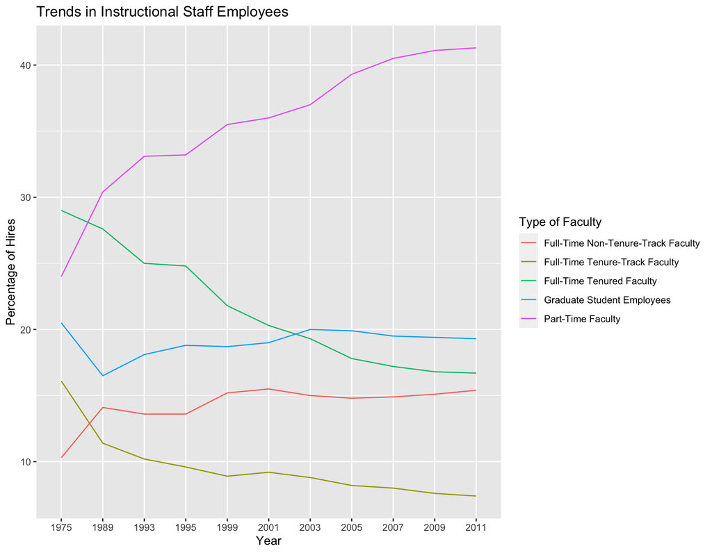

```r
staff_long %>%
  ggplot(aes(x = year, y = value, group = faculty_type, color = faculty_type)) + labs(title= "Trends in Instructional Staff Employees", color = "Type of Faculty", x= "Year", y= "Percentage of Hires" ) +
  geom_line()
```

### Exercise 2

You could also combine the other positions and do a part time vs everything else

### Exercise 3

```r
fisheries <- read_csv("data/fisheries.csv")
fisheries_new <- fisheries %>%
  pivot_longer(cols = -country, names_to = "Harvest") %>%
  filter(Harvest %in% c("capture", "aquaculture")) %>%
  mutate(value = as.numeric(value))
fisheries_new
```

```
## # A tibble: 432 × 3
##    country        Harvest     value
##    <chr>          <chr>       <dbl>
##  1 Afghanistan    capture      1000
##  2 Afghanistan    aquaculture  1200
##  3 Albania        capture      7886
##  4 Albania        aquaculture   950
##  5 Algeria        capture     95000
##  6 Algeria        aquaculture  1361
##  7 American Samoa capture      3047
##  8 American Samoa aquaculture    20
##  9 Andorra        capture         0
## 10 Andorra        aquaculture     0
## # … with 422 more rows
```

```r
fisheries_new <- fisheries_new %>%
  filter(country %in% c("China", "Russia", "Norway", "Malaysia", "Spain", "Nigeria", "France", "Mauritania", "Ghana", "Mozambique", "Poland", "Sierra Leone", "Laos", "Panama", "Seychelles", "Saudi Arabia"))
```

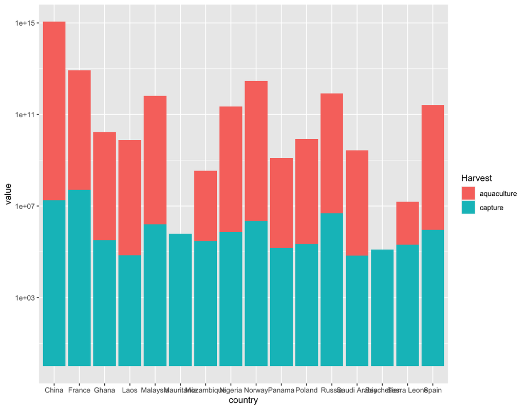

```r
fisheries_new %>%
  ggplot(mapping = aes(fill = Harvest, y=value, x=country)) + geom_bar(position="stack", stat="identity") + scale_y_log10()
```

I created a new variable, harvest, putting both aquaculture and capture in it so I could create a stacked bar chart. I then log scaled the y axis so you could see more. I then kept only the countries with the most, the ones that were in the chart provided. This made it look much better. I could also adjust the x axis to make it easier to read.

### Exerciser 4

```r
library(tidyverse)
library(mosaicData)
?Whickham
```

This is likely observational data since it is a survey.

```r
nrow(Whickham)
```

```
## [1] 1314
```

```r
ncol(Whickham)
```

```
## [1] 3
```

1314 observations, each is a person. 3 variables, representing if they are alive/dead, smoker or not, and age. I would expect the smokers to be more likely to be less healthy.

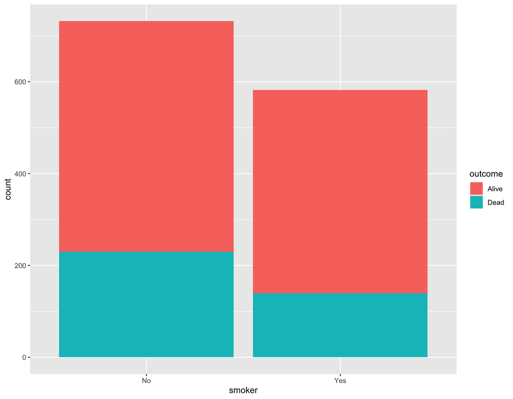

```r
Whickham %>%
  ggplot(mapping = aes(fill = outcome, x=smoker)) + geom_bar()
```

```r
Whickham %>%
  count(smoker, outcome)
```

```
##   smoker outcome   n
## 1     No   Alive 502
## 2     No    Dead 230
## 3    Yes   Alive 443
## 4    Yes    Dead 139
```

68.6% of Non smokers are alive 76% of smokers are alive

```r
Whickham <- Whickham %>%
  mutate(age_cat = case_when(
    age <= 44 ~ "18-44",
    age > 44 & age <= 64 ~ "45-64",
    age > 64 ~ "65+"
))
```

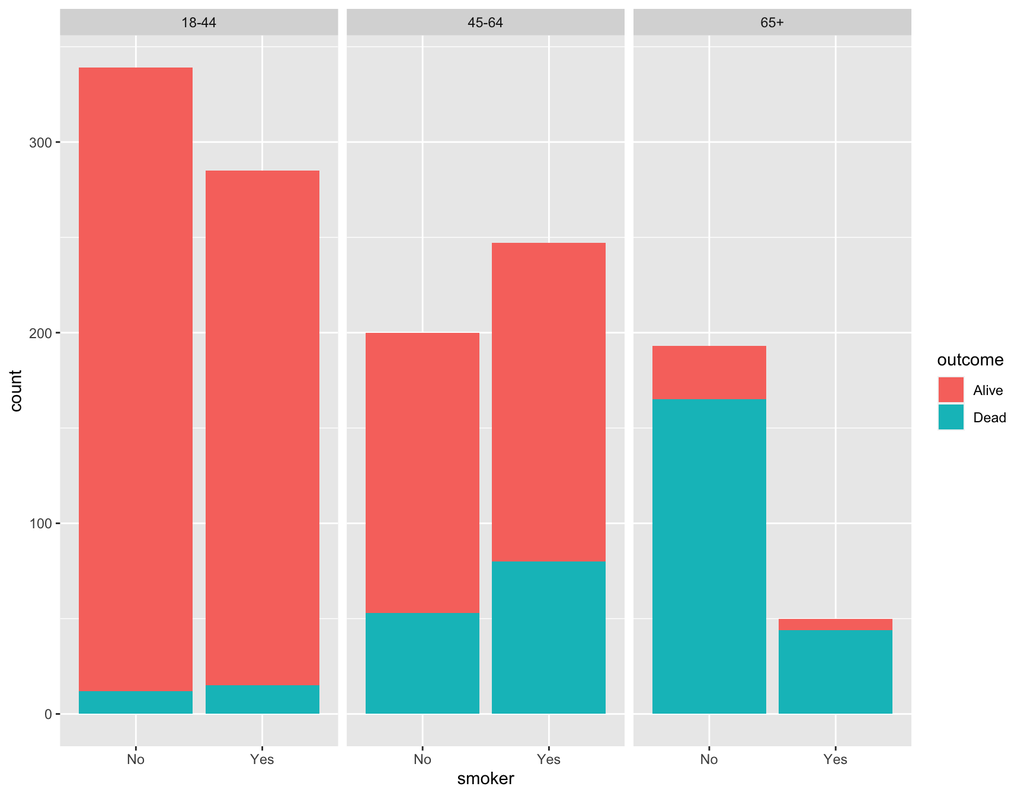

```r
Whickham %>%
  ggplot(mapping = aes(fill = outcome, x=smoker)) + facet_wrap(~age_cat)+geom_bar()
```

```r
Whickham %>%
  count(smoker, age_cat, outcome)
```

```
##    smoker age_cat outcome   n
## 1      No   18-44   Alive 327
## 2      No   18-44    Dead  12
## 3      No   45-64   Alive 147
## 4      No   45-64    Dead  53
## 5      No     65+   Alive  28
## 6      No     65+    Dead 165
## 7     Yes   18-44   Alive 270
## 8     Yes   18-44    Dead  15
## 9     Yes   45-64   Alive 167
## 10    Yes   45-64    Dead  80
## 11    Yes     65+   Alive   6
## 12    Yes     65+    Dead  44
```